# RPDR

Chaya Jones

March 4, 2019

| season_number | episode_number | t | contestant_id | contestant_name | ethnicity | asian | black | latino | white | drag_house_ind | z.age | z.past_wins | z.past_lipsync | z.past_top | z.past_safe | z.past_bottom | z.past_high | z.past_low | z.past_high_safe | plus_size | drag_fam_competed | puerto_rican | new_york_city | placement | num_winners | num_losers |
| --- | --- | --- | --- | --- | --- | --- | --- | --- | --- | --- | --- | --- | --- | --- | --- | --- | --- | --- | --- | --- | --- | --- | --- | --- | --- | --- |
| 11 | 6 | 122 | 130 | Vanessa Vanjie Mateo | latino | 0 | 0 | 1 | 0 | 1 | -0.28 | -0.35 | -0.29 | 0.13 | 0.14 | 0.12 | 0.43 | 0.45 | 0.34 | 0 | 1 | 1 | 0 | 0 | 0 | 0 |
| 11 | 6 | 122 | 131 | Nina West | white | 0 | 0 | 0 | 1 | 0 | 0.94 | 0.24 | -0.29 | -0.16 | 0.50 | 0.12 | -0.40 | 0.45 | 0.10 | 1 | 0 | 0 | 0 | 0 | 0 | 0 |
| 11 | 6 | 122 | 132 | Shuga Cain | latino | 0 | 0 | 1 | 0 | 0 | 1.03 | -0.35 | 1.30 | -0.16 | 0.14 | 0.62 | 0.01 | -0.30 | 0.10 | 0 | 0 | 0 | 1 | 0 | 0 | 0 |
| 11 | 6 | 122 | 133 | Plastique Tiara | vietnamese | 1 | 0 | 0 | 0 | 1 | -0.74 | -0.35 | 0.50 | 0.42 | -0.23 | 0.12 | 0.85 | -0.30 | 0.34 | 0 | 1 | 0 | 0 | 0 | 0 | 0 |
| 11 | 6 | 122 | 135 | Scarlet Envy | white | 0 | 0 | 0 | 1 | 0 | -0.28 | 0.24 | 0.50 | -0.16 | 0.50 | 0.12 | -0.40 | -0.30 | 0.10 | 0 | 1 | 0 | 1 | 0 | 0 | 0 |
| 11 | 6 | 122 | 137 | A’keria Chanel Davenport | black | 0 | 1 | 0 | 0 | 1 | 0.10 | -0.35 | 0.50 | -0.16 | 0.50 | 0.12 | 0.01 | -0.30 | 0.34 | 0 | 1 | 0 | 0 | 0 | 0 | 0 |
| 11 | 6 | 122 | 138 | Yvie Oddly | black | 0 | 1 | 0 | 0 | 0 | -0.46 | 0.24 | -0.29 | 0.42 | 0.14 | -0.39 | 0.43 | -0.30 | 0.34 | 0 | 0 | 0 | 0 | 0 | 0 | 0 |
| 11 | 6 | 122 | 139 | Silky Nutmeg Ganache | black | 0 | 1 | 0 | 0 | 0 | -0.09 | 0.24 | -0.29 | -0.16 | 0.50 | 0.12 | -0.40 | 0.45 | 0.10 | 1 | 0 | 0 | 0 | 0 | 0 | 0 |
| 11 | 6 | 122 | 140 | Brooke Lynn Hytes | white | 0 | 0 | 0 | 1 | 0 | 0.29 | 0.84 | -0.29 | 0.42 | -0.23 | 0.12 | 0.01 | 0.45 | -0.14 | 0 | 0 | 0 | 0 | 0 | 0 | 0 |
| 11 | 6 | 122 | 142 | Ra’jah D. O’Hara | black | 0 | 1 | 0 | 0 | 1 | 0.38 | -0.35 | 1.30 | -0.46 | 0.50 | 0.62 | -0.40 | -0.30 | 0.10 | 0 | 1 | 0 | 0 | 0 | 0 | 0 |

## Model

$$P[i^* \text{ wins episode }t] = \frac{\exp(\eta_{i^*t})}{\sum_i \exp(\eta_{it})}$$
$$P[i_* \text{ loses episode }t] = \frac{\exp(-\eta_{i_*t})}{\sum_{i \ne i^*} \exp(-\eta_{it})}$$
$$\alpha_i \sim N(0, \sigma)$$
We have [prior knowledge from large corpuses of logistic regressions](http://www.stat.columbia.edu/~gelman/research/published/priors11.pdf) to rule out unreasonable values for coefficients. We express this by putting a Student’s t prior on $\beta_\text{age}$ and $\beta_\text{past_wins}$. This is a reasonable default prior when coefficients should be close to zero but have some chance of being large. We put a half-Normal prior on $\sigma$. We follow the recommendations [here](https://github.com/stan-dev/stan/wiki/Prior-Choice-Recommendations).

```stan
data {
  int N; // number of contestant-episode observations
  int I; // number of contestants
  int T; // number of episodes
  int<lower=1,upper=I> ii[N]; // contestant for each observation
  int num_contestants[T]; // number of contestants for each episode
  vector[N] age;
  vector[N] plus_size;
  vector[N] drag_fam_competed;
  vector[N] asian;
  vector[N] black;
  vector[N] latino;
  vector[N] white;
  vector[N] puerto_rican;
  vector[N] new_york_city;
  vector[N] drag_house_ind;
  vector[N] past_lipsync;
  vector[N] past_wins;
  vector[N] past_top;
  vector[N] past_bottom;
  vector[N] past_high;
  vector[N] past_low;
  vector[N] past_safe;
  vector[N] past_high_safe;
}
parameters {
  real beta_age;
  real beta_plus_size;
  real beta_drag_fam_competed;
  real beta_asian;
  real beta_black;
  real beta_latino;
  real beta_white;
  real beta_puerto_rican;
  real beta_new_york_city;
  real beta_drag_house_ind;
  real beta_past_lipsync;
  real beta_past_wins;
  real beta_past_top;
  real beta_past_bottom;
  real beta_past_high;
  real beta_past_low;
  real beta_past_safe;
  real beta_past_high_safe;
  vector[I] alpha_contestant_raw;
  real<lower=0> sigma;
}
transformed parameters {
  vector[I] alpha_contestant = alpha_contestant_raw * sigma;
}
model {
  // vector[N] eta = beta_age * age + beta_past_wins * past_wins + alpha_contestant[ii];
  // vector[N] eta = beta_puerto_rican * puerto_rican + beta_drag_house_ind * drag_house_ind + beta_past_lipsync * past_lipsync + beta_past_low * past_low + beta_past_safe * past_safe + beta_past_high * past_high + beta_past_wins * past_wins + alpha_contestant[ii];
  // vector[N] eta = beta_puerto_rican * puerto_rican + beta_drag_house_ind * drag_house_ind + beta_past_lipsync * past_lipsync + beta_past_low * past_low + beta_past_high * past_high + beta_past_wins * past_wins + alpha_contestant[ii];
  vector[N] eta = beta_puerto_rican * puerto_rican + beta_drag_house_ind * drag_house_ind + beta_past_lipsync * past_lipsync + beta_past_low * past_low + beta_past_high_safe * past_high_safe + beta_past_wins * past_wins + alpha_contestant[ii];
  beta_age ~ student_t(6,0,2.5);
  beta_plus_size ~ student_t(6,0,2.5);
  beta_drag_fam_competed ~ student_t(6,0,2.5);
  beta_asian ~ student_t(6,0,2.5);
  beta_black ~ student_t(6,0,2.5);
  beta_latino ~ student_t(6,0,2.5);
  beta_white ~ student_t(6,0,2.5);
  beta_puerto_rican ~ student_t(6,0,2.5);
  beta_new_york_city ~ student_t(6,0,2.5);
  beta_drag_house_ind ~ student_t(6,0,2.5);
  beta_past_lipsync ~ student_t(6,0,2.5);
  beta_past_wins ~ student_t(6,0,2.5);
  beta_past_top ~ student_t(6,0,2.5);
  beta_past_bottom ~ student_t(6,0,2.5);
  beta_past_high ~ student_t(6,0,2.5);
  beta_past_low ~ student_t(6,0,2.5);
  beta_past_safe ~ student_t(6,0,2.5);
  beta_past_high_safe ~ student_t(6,0,2.5);
  alpha_contestant_raw ~ normal(0,1);
  sigma ~ normal(0,1);
  { int pos;
  pos = 1;
  for (t in 1:T) {
    vector[num_contestants[t]] eta_t = segment(eta, pos, num_contestants[t]);
    target += eta_t[1] - log_sum_exp(eta_t);
    target += -1*eta_t[rows(eta_t)] - log_sum_exp(-1*eta_t[2:rows(eta_t)]); // remove winner (listed first)
    pos = pos + num_contestants[t];
  }}
}
```

```r
fit_model <- function(df) {
  standata <- list(
    N = nrow(df),
    I = max(df$contestant_id),
    T = max(df$t),
    ii = df$contestant_id,
    num_contestants = (df %>% group_by(t) %>% summarise(n = n()))$n,
    age = df$z.age,
    plus_size = df$plus_size,
    drag_fam_competed = df$drag_fam_competed,
    asian = df$asian,
    black = df$black,
    latino = df$latino,
    white = df$white,
    puerto_rican = df$puerto_rican,
    new_york_city = df$new_york_city,
    drag_house_ind = df$drag_house_ind,
    past_lipsync = df$z.past_lipsync,
    past_wins = df$z.past_wins,
    past_high = df$z.past_high,
    past_low = df$z.past_low,
    past_safe = df$z.past_safe,
    past_high_safe = df$z.past_high_safe,
    past_top = df$z.past_top,
    past_bottom = df$z.past_bottom
  )
  sampling(object = model, data = standata, chains = 4, iter = 2000, control = list(adapt_delta = 0.99))
}
data_so_far <- wrangled %>% filter(t < next_t)
fit <- fit_model(df = data_so_far)
```

```r
# 'beta_asian', 'beta_latino',
# print(fit, pars = c('beta_puerto_rican', 'beta_drag_house_ind', 'beta_past_lipsync', 'beta_past_low', 'beta_past_safe', 'beta_past_high', 'beta_past_wins', 'sigma'))
# stan_plot(fit, pars = c('beta_puerto_rican', 'beta_drag_house_ind', 'beta_past_lipsync', 'beta_past_low', 'beta_past_safe', 'beta_past_high', 'beta_past_wins', 'sigma')) + geom_vline(xintercept=0, size = 2)

# print(fit, pars = c('beta_puerto_rican', 'beta_drag_house_ind', 'beta_past_lipsync', 'beta_past_low', 'beta_past_high', 'beta_past_wins', 'sigma'))
# stan_plot(fit, pars = c('beta_puerto_rican', 'beta_drag_house_ind', 'beta_past_lipsync', 'beta_past_low', 'beta_past_high', 'beta_past_wins', 'sigma')) + geom_vline(xintercept=0, size = 2)

print(fit, pars = c('beta_puerto_rican', 'beta_drag_house_ind', 'beta_past_lipsync', 'beta_past_low', 'beta_past_high_safe', 'beta_past_wins', 'sigma'))
```

```
## Inference for Stan model: 5186139f170e3dd50ea8bed42e40b5b0.
## 4 chains, each with iter=2000; warmup=1000; thin=1;
## post-warmup draws per chain=1000, total post-warmup draws=4000.
##
##                      mean se_mean   sd  2.5%   25%   50%   75% 97.5% n_eff
## beta_puerto_rican   -0.36    0.01 0.45 -1.24 -0.65 -0.37 -0.07  0.56  2941
## beta_drag_house_ind  0.37    0.01 0.33 -0.26  0.15  0.35  0.58  1.08  2114
## beta_past_lipsync   -0.63    0.01 0.36 -1.35 -0.87 -0.63 -0.39  0.06   993
## beta_past_low       -0.22    0.01 0.38 -0.95 -0.48 -0.22  0.04  0.52  1013
## beta_past_high_safe  1.47    0.02 0.95 -0.33  0.82  1.46  2.11  3.32  1799
## beta_past_wins      -0.12    0.03 0.62 -1.38 -0.54 -0.12  0.30  1.07   376
## sigma                1.05    0.02 0.36  0.35  0.80  1.05  1.28  1.77   229
##                     Rhat
## beta_puerto_rican   1.00
## beta_drag_house_ind 1.00
## beta_past_lipsync   1.01
## beta_past_low       1.00
## beta_past_high_safe 1.00
## beta_past_wins      1.01
## sigma               1.02
##
## Samples were drawn using NUTS(diag_e) at Sun Mar 31 01:25:03 2019.
## For each parameter, n_eff is a crude measure of effective sample size,
## and Rhat is the potential scale reduction factor on split chains (at
## convergence, Rhat=1).
```

```
## ci_level: 0.8 (80% intervals)
```

```
## outer_level: 0.95 (95% intervals)
```

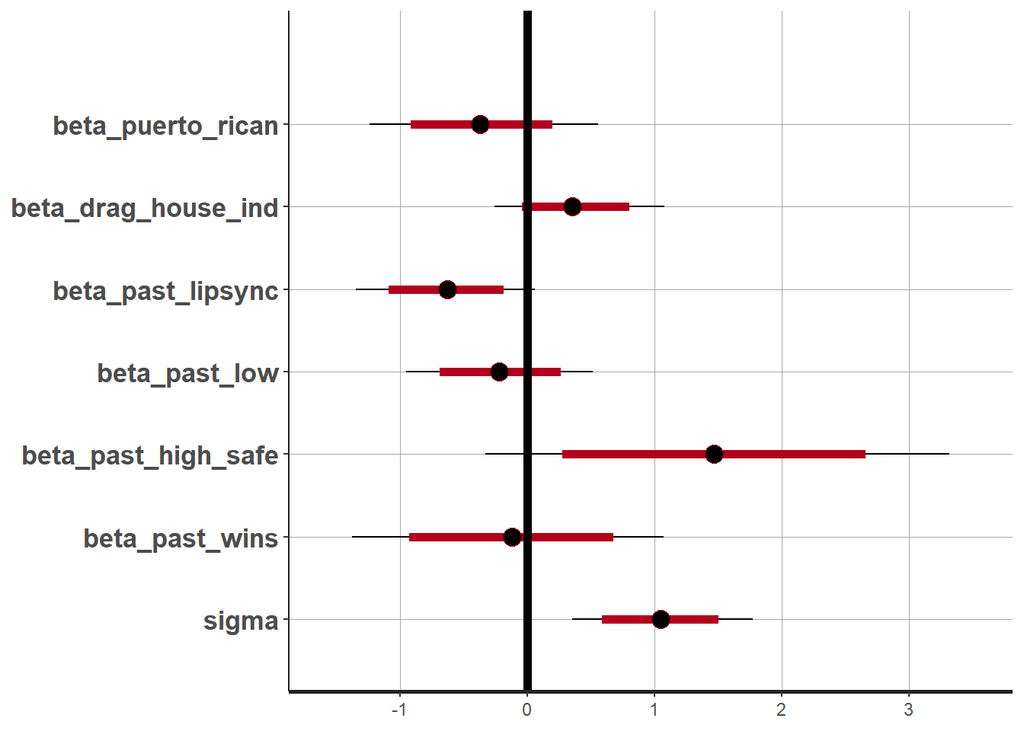

```r
stan_plot(fit, pars = c('beta_puerto_rican', 'beta_drag_house_ind', 'beta_past_lipsync', 'beta_past_low', 'beta_past_high_safe', 'beta_past_wins', 'sigma')) + geom_vline(xintercept=0, size = 2)
```

To estimate the predictive performance for new episodes we use *leave-future-out cross-validation*:

```r
Mode <- function(x) {
  ux <- unique(x)
  ux[which.max(tabulate(match(x, ux)))]
}
L = 30 # always use at least L past episodes of data
correct_win = c()
correct_lose = c()
random_correct = c()
# this will take a long time!
# s$beta_asian * newdata$asian + s$beta_latino * newdata$latino +
for (t_current in (L+1):(next_t - 1)) {
  data_current <- wrangled %>% filter(t < t_current) # leave-future-out
  fit_current <- fit_model(df = data_current)
  newdata <- wrangled %>% filter(t == t_current)
  s <- as.data.frame(fit_current) # simulations from the posterior
  eta_s <- matrix(NA, nrow = nrow(s), ncol = nrow(newdata))
  for (n in 1:nrow(newdata)) {
    i = newdata$contestant_id[n]
    if (is.element(i,data_current$contestant_id)) { # we have seen this contestant before
      alpha_contestant_s <- s[,c(paste('alpha_contestant[',i,']',sep=''))]
    } else { # this is a new contestant
      alpha_contestant_s <- rnorm(n = nrow(s), mean = 0, sd = s$sigma)
    }
    # eta_s[,n] <- s$beta_puerto_rican * newdata$puerto_rican + s$beta_drag_house_ind * newdata$drag_house_ind + s$beta_past_lipsync * newdata$z.past_lipsync[n] + s$beta_past_low * newdata$z.past_low[n] + s$beta_past_safe * newdata$z.past_safe[n] + s$beta_past_high * newdata$z.past_high[n] + s$beta_past_wins * newdata$z.past_wins[n] + alpha_contestant_s

    # eta_s[,n] <- s$beta_puerto_rican * newdata$puerto_rican + s$beta_drag_house_ind * newdata$drag_house_ind + s$beta_past_lipsync * newdata$z.past_lipsync[n] + s$beta_past_low * newdata$z.past_low[n] + s$beta_past_high * newdata$z.past_high[n] + s$beta_past_wins * newdata$z.past_wins[n] + alpha_contestant_s

    eta_s[,n] <- s$beta_puerto_rican * newdata$puerto_rican + s$beta_drag_house_ind * newdata$drag_house_ind + s$beta_past_lipsync * newdata$z.past_lipsync[n] + s$beta_past_low * newdata$z.past_low[n] + s$beta_past_high_safe * newdata$z.past_high_safe[n] + s$beta_past_wins * newdata$z.past_wins[n] + alpha_contestant_s
  }
  winner_s <- apply(eta_s, MARGIN = 1, FUN = which.max)
  pred_winner <- Mode(winner_s)
  loser_s <- apply(eta_s, MARGIN = 1, FUN = which.min)
  pred_loser <- Mode(loser_s)
  correct_win <- c(correct_win, (newdata$placement[pred_winner] == 1))
  correct_lose <- c(correct_lose, (newdata$placement[pred_loser] == -1))
  random_correct = c(random_correct, (1/nrow(newdata))*(1/(nrow(newdata)-1)))
}
```

We get 13% accuracy for winners with our model. We get 27% accuracy for losers with our model. A random guess gets 3% accuracy. Can your model do better?

Sidenote: Computing leave-future-out cross-validation above took a long time. For an approximate leave-future-out cross-validation that is much faster, see [this paper](https://github.com/paul-buerkner/LFO-CV-paper/blob/master/LFO-CV.pdf).

## Predict and submit

Let’s now use our model to predict the winner and loser of the next episode:

```r
Mode <- function(x) {
  ux <- unique(x)
  ux[which.max(tabulate(match(x, ux)))]
}
newdata <- wrangled %>% filter(t == next_t)
s <- as.data.frame(fit) # simulations from the posterior
eta_s <- matrix(NA, nrow = nrow(s), ncol = nrow(newdata))
for (n in 1:nrow(newdata)) {
  i = newdata$contestant_id[n]
  if (is.element(i,data_so_far$contestant_id)) { # we have seen this contestant before
    alpha_contestant_s <- s[,c(paste('alpha_contestant[',i,']',sep=''))]
  } else { # this is a new contestant
    alpha_contestant_s <- rnorm(n = nrow(s), mean = 0, sd = s$sigma)
  }
    # eta_s[,n] <- s$beta_puerto_rican * newdata$puerto_rican + s$beta_drag_house_ind * newdata$drag_house_ind + s$beta_past_lipsync * newdata$z.past_lipsync[n] + s$beta_past_low * newdata$z.past_low[n] + s$beta_past_safe * newdata$z.past_safe[n] + s$beta_past_high * newdata$z.past_high[n] + s$beta_past_wins * newdata$z.past_wins[n] + alpha_contestant_s

    # eta_s[,n] <- s$beta_puerto_rican * newdata$puerto_rican + s$beta_drag_house_ind * newdata$drag_house_ind + s$beta_past_lipsync * newdata$z.past_lipsync[n] + s$beta_past_low * newdata$z.past_low[n] + s$beta_past_high * newdata$z.past_high[n] + s$beta_past_wins * newdata$z.past_wins[n] + alpha_contestant_s

    eta_s[,n] <- s$beta_puerto_rican * newdata$puerto_rican + s$beta_drag_house_ind * newdata$drag_house_ind + s$beta_past_lipsync * newdata$z.past_lipsync[n] + s$beta_past_low * newdata$z.past_low[n] + s$beta_past_high_safe * newdata$z.past_high_safe[n] + s$beta_past_wins * newdata$z.past_wins[n] + alpha_contestant_s
}
winner_s <- apply(eta_s, MARGIN = 1, FUN = which.max)
pred_winner <- Mode(winner_s)
loser_s <- apply(eta_s, MARGIN = 1, FUN = which.min)
pred_loser <- Mode(loser_s)
```

We predict Brooke Lynn Hytes will win and Ra’jah D. O’Hara will lose.